# Tutorial for Creating Annotated SVGs

Jianhai Zhang (jzhan067@ucr.edu)

Last update: 24 November, 2024

Maintainer: Jianhai Zhang

# 1 Introduction

The [*spatialHeatmap*](http://bioconductor.org/packages/3.18/bioc/html/spatialHeatmap.html) package offers a generic and flexible environment for visualizing spatial bulk and single-cell assays in anatomical images. It colors spatial features (e.g. tissues) annotated in the images according to the quantitative abundance levels of measured biomolecules (e.g. mRNAs) using a color key. This core functionality of the package is called a spatial heatmap (SHM) plot. Single-cell data can be co-visualized in composite plots that combine SHMs with embedding plots of high-dimensional data. Additional important functionalities include the automated identification of biomolecules with spatially selective abundance patterns and clusters of biomolecules sharing similar abundance profiles.

To plot SHMs, a pair of assay data and anatomical image is required. The format of the latter should be annotated Scalable Vector Graphics (aSVG), where spatial features such as cells, tissues, and organs are annotated with unique identifiers. In addition to the public SVG repository [EBI anatomogram](https://github.com/ebi-gene-expression-group/anatomogram/tree/master/src/svg), *spatialHeatmap* also supports custom aSVGs, which is one of the most important features. This tutorial explains how to create custom aSVGs for plotting SHMs. *spatialHeatmap* offers its own SVG repository ([SHM SVG repo](https://github.com/jianhaizhang/SVG_tutorial)) for depositing aSVGs created using this tutorial (SHM SVGs). Furthermore, the Supplement provides information on converting SHM SVG format to EBI SVG format.

# 2 Getting Started

First, install the `spatialHeatmap` package from Bioconductor.

```r
if (!requireNamespace("BiocManager", quietly = TRUE))
    install.packages("BiocManager")
BiocManager::install("spatialHeatmap")
```

Next, the packages required for running the sample code in this tutorial need to be loaded.

```r
library(spatialHeatmap); library(SummarizedExperiment); library(GEOquery)
```

The following lists the vignette(s) of *spatialHeatmap* in an HTML browser. Clicking the corresponding name will open this vignette.

```r
browseVignettes('spatialHeatmap')
```

# 3 Creating SVGs

This tutorial showcases the creation of custom aSVGs using the SVG editor [Inkscape](https://inkscape.org). Within Inkscape, there are three methods for generating spatial features: drawing with templates, employing geometric shapes, and utilizing [GIMP](https://www.gimp.org).

## 3.1 Drawing with Templates

A template is a raster image that contains spatial features. An example template of *Arabidopsis thaliana* (Arabidopsis) root is provided [here](https://github.com/jianhaizhang/SVG_tutorial/blob/master/download/root.png) (Mustroph et al. 2009). Download this template and open it in Inkscape (Figure 1A). Select “Draw Bezier curves and straight lines (shift+F6)” on the left tool bar (Figure 1B).

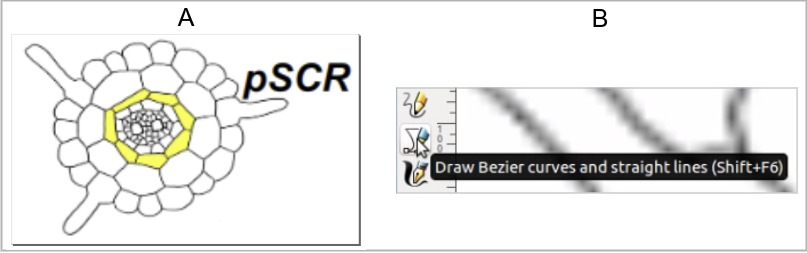

Figure 1: Open the template in Inkscape

Select “Fill and Stroke…” under the “Object” tab on the top (Figure 2A). On the right panel “Fill and Stroke (Shift+Ctrl+F)”, set “Stroke style” 3.000 px (Figure 2B) and press “Enter” key.

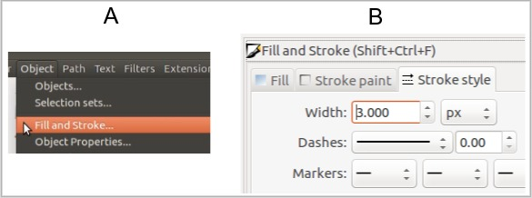

Figure 2: Open the ‘Fill and Stroke’ panel

Press the “+” key to zoom in and select a template shape to start. Draw an outline for each shape by clicking at differencet corners of the shape (Figure 3A-B). At last, click at the start point to seal the outline (Figure 3C), then a spatial feature is created.

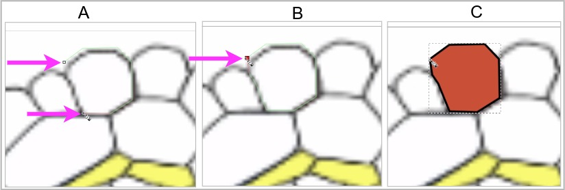

Figure 3: Drawing spatial features with a tempate

If the created spatial feature is filled with a color, click “No paint” under the “Fill” tab on the panel “Fill and Stroke (Shift+Ctrl+F)” (Figure 4A). Then it will become transparent (Figure 4B).

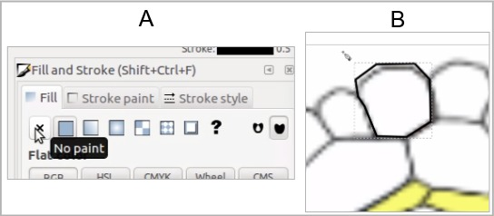

Figure 4: Transparent spatial features

Select “Edit paths by nodes (F2)” on the left tool bar (Figure 5A), and draw a rectangle over the created spatial feature (Figure 5B). Select “Make selected nodes corner” (Figure 5C) on the top.

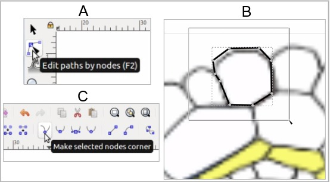

Figure 5: Turn nodes to corners

Drag nodes and edges to well align the spatial feature with the template shape (Figure 6A). On the fill and stroke panel, under the “Fill” tab select “Flat color” and optionally adjust the color scales to label the spatial feature (Figure 6B). Then the first spatial feature is done (Figure 6C).

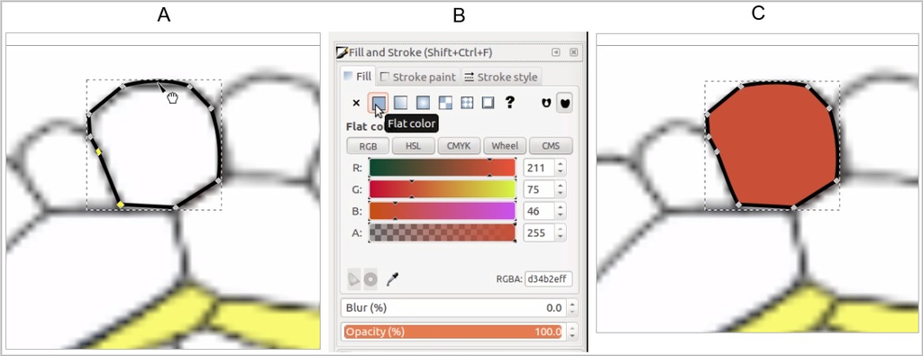

Figure 6: Refine spatial features

## 3.2 Using Geometric Shapes

This section showcases transforming basic geometric shapes (e.g. rectangles and circles) into spatial features, serving as a method to create the second spatial feature.

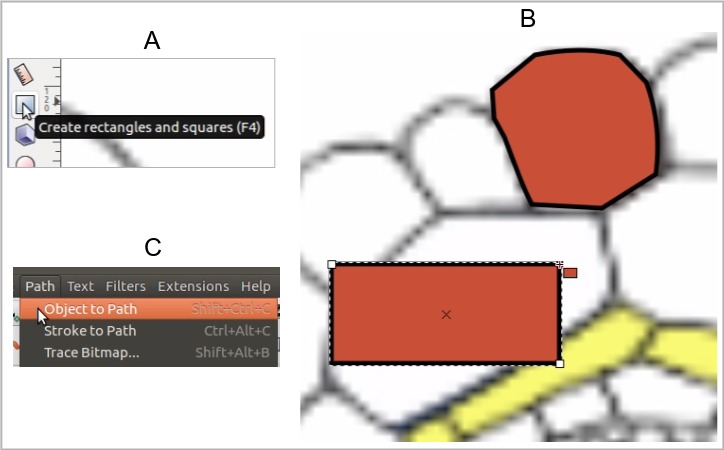

Figure 7: Converting geometric shapes into paths

Click “No paint” under the “Fill” tab on the fill and stroke panel to make the rectangle transparent (Figure 8A). Rotate the rectangle if needed (Figure 8B). Select “Edit paths by nodes (F2)” on the left tool bar. If necessary, add a node by double-clicking on an edge (Figure 8C). Drag nodes and edges to align the rectangle with the underlying shape template (Figure 8C).

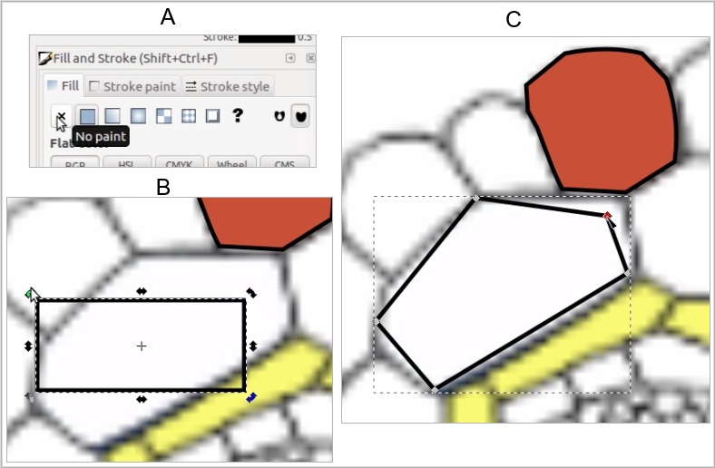

Figure 8: Adding nodes to rectangles

Select “Edit paths by nodes (F2)” on the left tool bar (Figure 9A), and draw a rectangle over the spatial feature (Figure 9B). Select “Make selected nodes corner” on the top (Figure 9C).

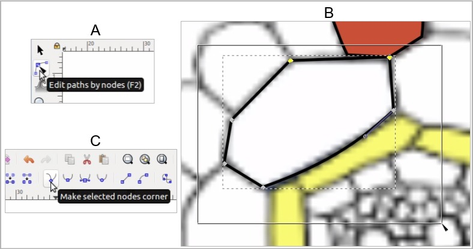

Figure 9: Aligning rectangles with template shapes

Drag the handles at the nodes of the spatial feature to fine adjust the edges for alignment with the template shape (Figure 10A). On the fill and stroke panel select “Flat color” under the “Fill” tab to optionally color this spatial feature (Figure 10B). Then the second spatial feature is done.

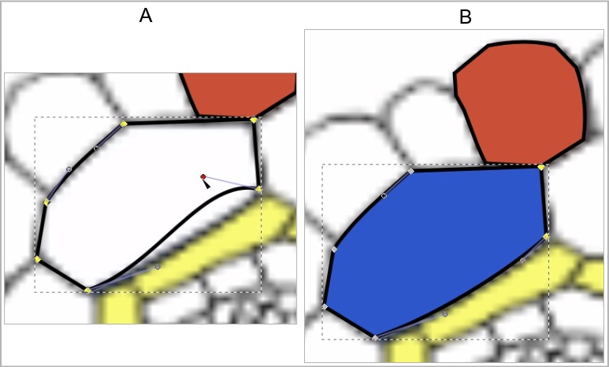

Figure 10: Spatial features created with geometric shapes

## 3.3 Using GIMP

If shapes in the template image have clear outlines, the SVG image can be automatically extracted with [GIMP](https://www.gimp.org/). Note, unclear outlines would lead to extraction of messy spatial feature.

### 3.3.1 Extracting Shapes

Open the template image in GIMP (Figure 11A), then open the “Paths” panel (Figure 11B-C). Right click and select “By Color” (Figure 11D).

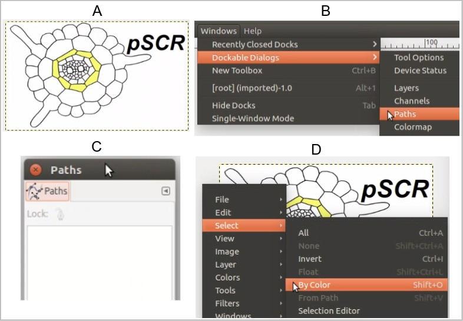

Figure 11: Selecting shapes by colors

Now the shapes can be selected by colors. For exmaple, first click on a whilte shape to select all shapes in white, then right click and select “To Path” (Figure 12A). After that, all the white shapes are extracted to the “Paths” panel (Figure 12B). Similarly, extract shapes of other colors.

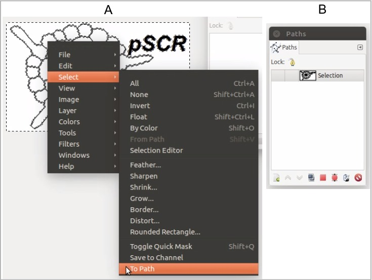

Figure 12: Exporting shapes to paths

Click in front of each extracted shape to show the “eye” icon (Figure 13A). Mouse over the extracted shapes, right click, select “Merge Visible Paths” (Figure 13B). After merged, export the paths as an SVG image (here root_gimp.svg) (Figure 13C). Next, proceed to edit the exported SVG image in Inkscape.

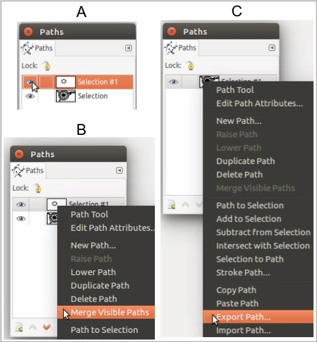

Figure 13: Exporting shapes as an SVG file

### 3.3.2 Edit the Extracted SVG

Open the exported SVG image (root_gimp.svg) in Inkscape (Figure 14A). Under ‘Object’ tab at the top, select “Fill and Stroke…” (Figure 2A). To make all shapes visible, click the image, select “Flat color” the under “Fill” tab, then adjust color scales (Figure 14B-C).

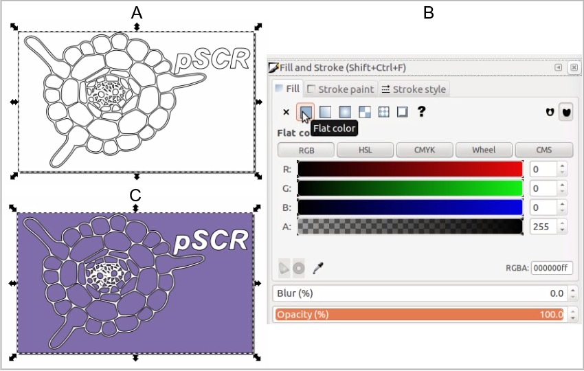

Figure 14: Opening the extracted SVG in Inkscape

By default, all shapes (paths) in the SVG image extracted by GIMP are combined as a whole. To separate them, first click the image then click “Break Apart” under the top “Path” tab (Figure 15A). After separated, the shape outlines are not stroked by default. To stroke the outlines, first use “Ctrl+A” to select all shapes, on the fill and stroke panel select “Flat color” under the “Stroke paint” tab (Figure 15B), then set a number under the “Stroke style” tab (e.g. 1.333 px) (Figure 15C).

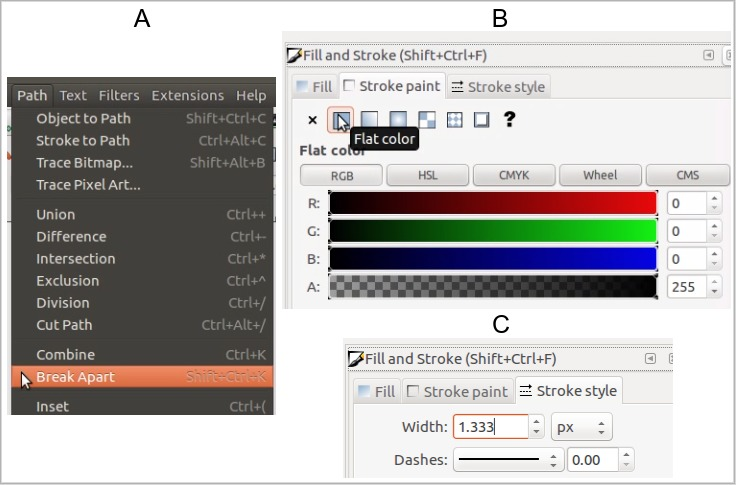

Figure 15: Breaking combined paths

Click anywhere in the white area to unselect the whole image. Press “+” key to zoom in, then move certain shapes to expected locations if needed. To delete byproduct shapes, first select them then press the “Delete” key (Figure 16A-C).

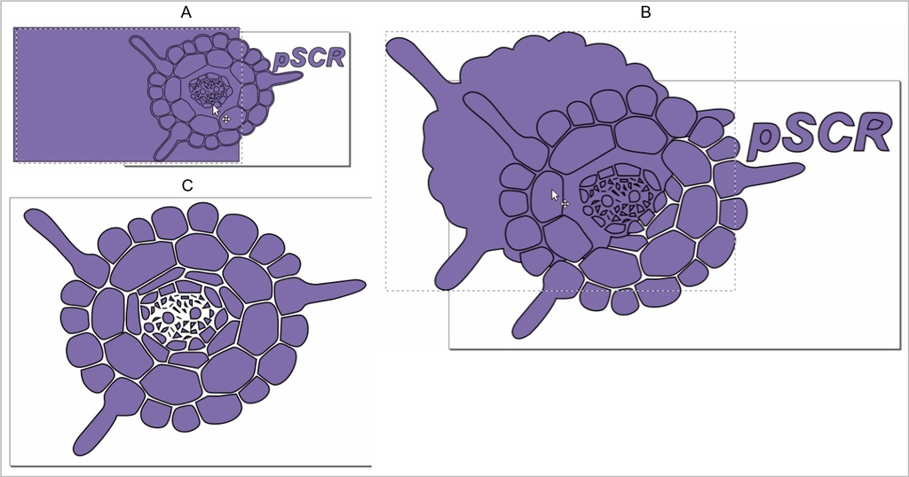

Figure 16: Deleting byproduct shapes

Use “Ctrl+A” to select all shapes. Click “No paint” under the “Fill” tab on the fill and stroke panel (Figure 17A). Click anywhere in the white area to unselect the whole image. Then the editing of the extracted SVG by GIMP is done. The edited SVG file (Figure 17B) is downloadable [here](https://raw.githubusercontent.com/jianhaizhang/SVG_tutorial_file/master/download/root_gimp_blank.svg).

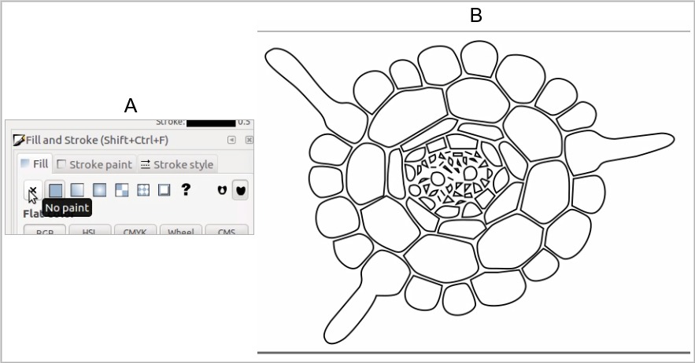

Figure 17: Edited SVGs

## 3.4 Dealing with Many Shapes

If the SVG image includes numerous spatial features (Figure 18A), the speed of creating SHMs in *spatialHeatmap* could be compromised. In such cases, a workaround is to overlay elongated and thin shapes existing in two layers to visually represent smaller shapes (Figure 18B). This strategy allows shared borders between spatial features and thus improves the runtime when *spatialHeatmap* extracting coordinates of the spatial features.

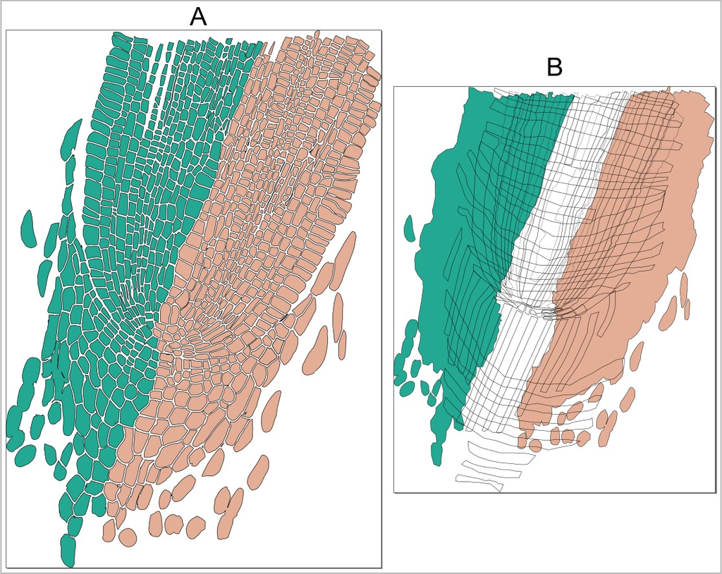

Figure 18: SVGs including many spatial features

# 4 Formatting SVGs

For plotting SHMs with *spatialHeatmap*, the spatial features in the SVGs should be formatted according to some conventions. This section focuses on the details of formatting SVGs. In addition, SVGs from [EBI Anatomogram](https://github.com/ebi-gene-expression-group/anatomogram/tree/master/src/svg) are also supported in *spatialHeatmap*.

## 4.1 Grouping

If a complex spatial feature consists of multile sub-features, these sub-features should be grouped rather than combined (Ctrl+K). Take the root atrichoblast epidermis feature as example. First, select the sub-features of this tissue by clicking their edges while holding down the “Shift” key (Figure 19A). Next, mouse over any edge of the selected sub-features, then right-click and choose “Group” (Figure 19B). Note, if the spatial features are not expected to be colored in SHMs, it is not necessary to group them.

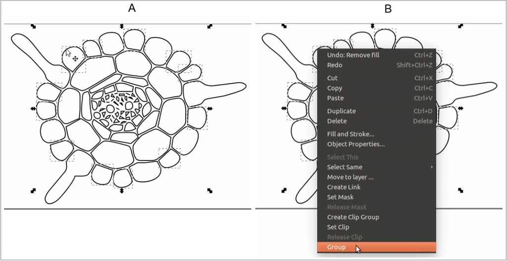

Figure 19: Grouping spatial features

In order to make the grouped spatial features visually different from other features, the group can be colored. Sepecifically, click “Flat color” under the “Fill” tab on the fill and stroke panel (Figure 20A), then fill the group with a preferred color (Figure 20B).

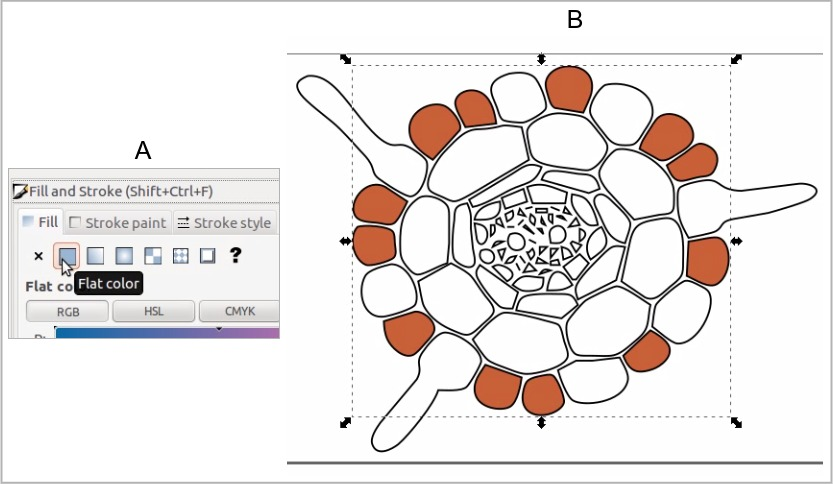

Figure 20: Coloring the grouped spatial features

## 4.2 Resizing Groups

A group (e.g. root_pSCR/root endodermis in Figure 21B) could be resized by simply dragging the black arrows on the edge or changing the width (H), height (H) values on the top toolbar. In either case, in the “XML Editor” panel the resized group would have an attribute of `transform` with a value of `matrix` (Figure 21B), indicating the coordinates of this group are transformed because of resizing. *spatialHeatmap* does not accept this “tranform-matrix” pair in groups. To remove this attribute, simply ungroup (Ctrl+Shift+G) and regroup (Ctrl+G) the relevant spatial features.

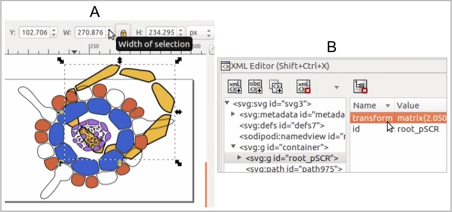

Figure 21: Resizing grouped spatial features

## 4.3 Annotating

To enable coloring based on numeric values in the assay data, it’s necessary for spatial features to be annotated with unique identifiers that correspond to their counterparts in the data. The annotated SVGs are referred to as aSVGs. For grouped features, the group rather individual features needs to be annotated. Figure 22 is the annotating of the “root_pGL2” (root atrichoblast epidermis) group. Specifically, under the “Edit” tab on the top (Figure 22A), select “XML Editor…” (Figure 22B). Click the “root_pGL2” feature to select it. On the “XML Editor (Shift+Ctrl+X)” panel, first click “id”, then type in “root_pGL2” and click “Set” at the bottom. Note, if the spatial features are not expected to be colored in SHMs, it is not necessary to annotate them.

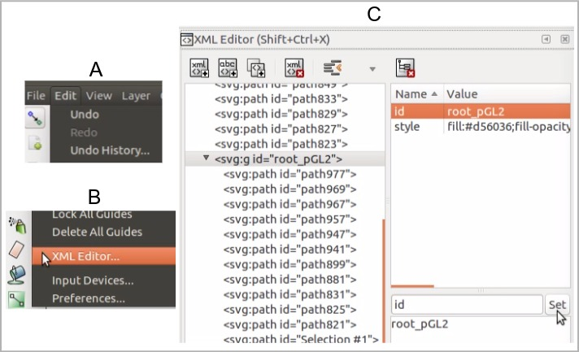

Figure 22: Annotating spatial features

In addition, it is optional to add an “ontology” attribute for spatial features. Take the spatial feature “root_pGL2” (root atrichoblast epidermis) as an example. First, retrieve the ontology id for this feature at [Ontology Lookup Service](https://www.ebi.ac.uk/ols/index). Click the feature in the XML Editor, at the bottom type “ontology” and the retreived id in front of and below “Set” respectively, then click “Set” (Figure 23).

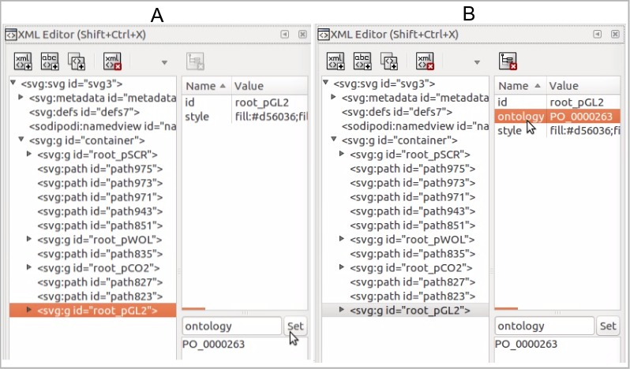

Figure 23: Adding ontology ids to spatial features

Similarly, group and annotate other spatial features as required. When grouping the small vasculature features in the center, a shortcut is to draw a rectangle over them to select multiple features, instead of clicking on each one individually. Figure 24 is the final aSVG of Arabidopsis root, colors representing different spatial features.

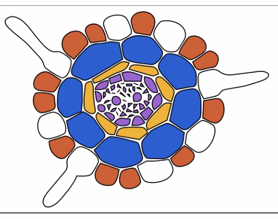

Figure 24: The aSVG of Arabidopsis root

## 4.4 Text Group

It is optional to include text in the aSVG. First click “Create and edit text objects (F8)” on the left tool bar (Figure 25A), then click on the target position and type text, here “root_pGL2” (Figure 25B).

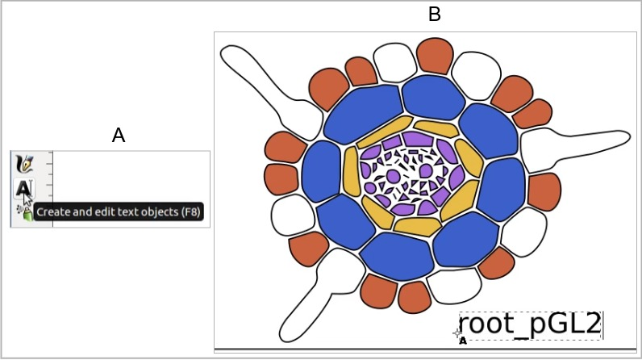

Figure 25: Adding text to aSVGs

On top tool bar, click on “View and select font family, font size, and other text properties (Shift+Ctrl+T)” (Figure 26A), then on the text panel, change text styles such as font size (Figure 26B).

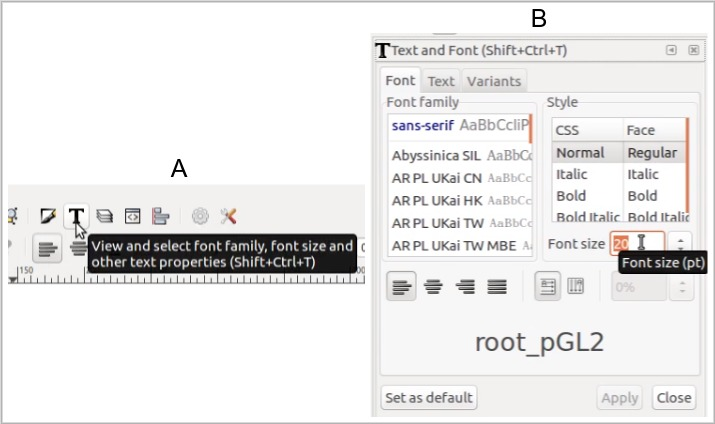

Figure 26: Changing text styles

Select the text object and convert it to path (Figure 27), then the text becomes a group (indicated by “svg:g” in Figure 27B).

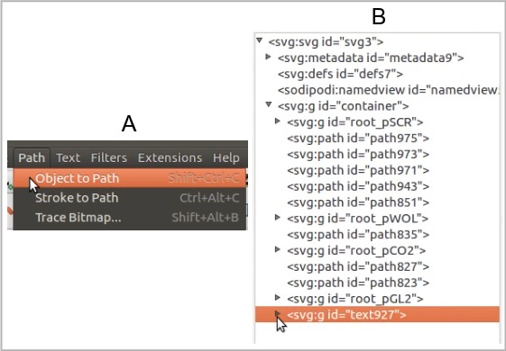

Figure 27: Converting text objects to paths

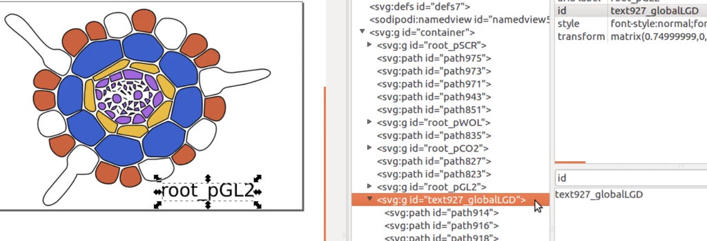

Figure 28: Text group ids

## 4.5 Shapes with Fixed Colors

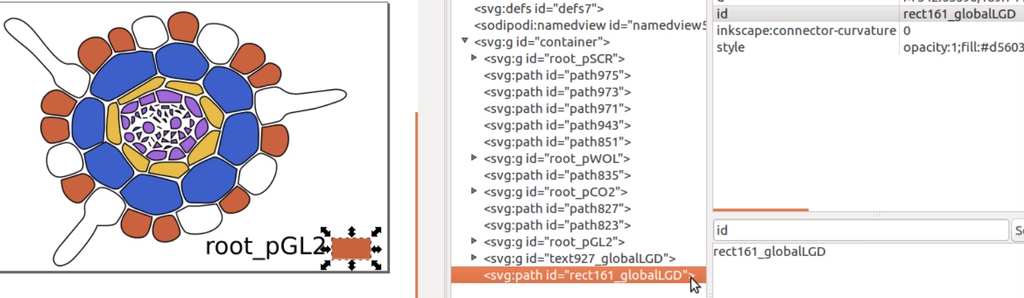

Figure 29: Non-text shapes

## 4.6 Final Grouping

All shapes, including text, need to be grouped as a whole. The id of this overall group can be random. To achieve this, select all the shapes using “Ctrl+A,” mouse over the selection, right-click, and then click “Group” (Figure 30A). It’s important to note that this overall group must be the last element in the ‘XML Editor’ (Figure 30B).

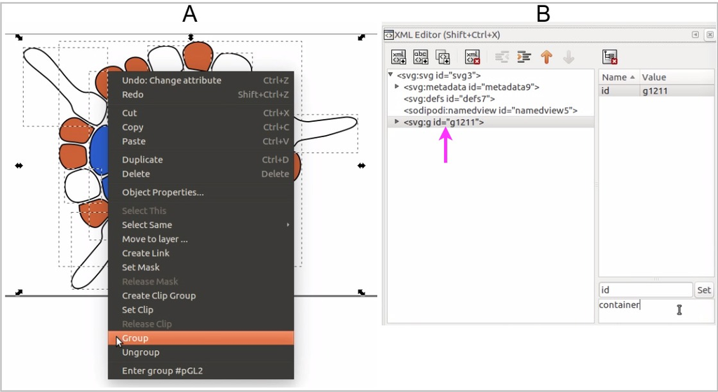

Figure 30: Grouping all shapes

## 4.7 Absolute Positions

All the shapes need to have absolute positions. To achieve so, click “Preferences…” under the “Edit” tab (Figure 31A). Next, go to “Input/Output” → “SVG Output” → “Path data” → “Path string format”, then select “Absolute” (Figure 31B). To trigger the effcts on all shapes, click “Select All in All Layers” under the “Edit” tab (Figure 31C), and use the arrow key to nudge the selection, e.g. one step forward and one step backward. Then all the shapes are rewritten and absolutely positioned. The absolut position is indicated by the capital letters (M, C, etc.) in the “d” attribute of a shape (Figure 31D).

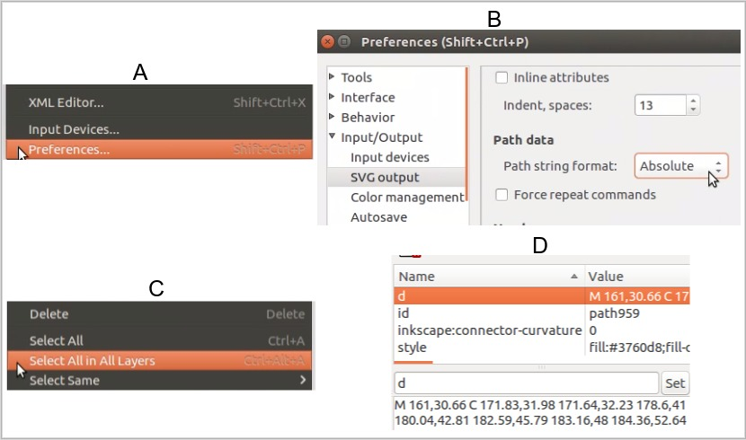

Figure 31: Absolution postitions for each shape

## 4.8 Resizing Canvas

To ensure the best overall height and width of the aSVG, go to “Document Properties…” under the “File” tab and select “Custom size” under the “Page” tab, then set “Units” to “px” and click on “Resize page to drawing or selection” (Figure 32). The fully formatted Arabidopsis root aSVG file is downloadable [here](https://raw.githubusercontent.com/jianhaizhang/SVG_tutorial/master/download/arabidopsis.thaliana_root.cross_shm.svg).

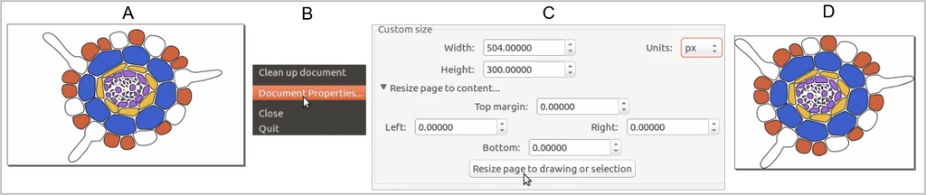

Figure 32: Adjusting overall height and width of the aSVG

## 4.9 Naming Scheme

In *spatialHeatmap*, the naming convention for the aSVG file follows the pattern “<species>_[view]_shm.svg,” for example, “arabidopsis.thaliana_root.cross_shm.svg.” It’s important to note that the aSVG file name must end with “.svg,” and the beginning of the file name should only include letters, digits, dots, or underscores. Parentheses should be avoided. For instance, a name like “arabidopsis.thaliana_root.cross_shm(1).svg” is not supported.